# PreProcessaBaseParaibaDoSul

```python
from zipfile import ZipFile
import pandas as pd
import numpy as np
import matplotlib.pyplot as plt
import seaborn as sns
```

```python
baseDadosZipada = ZipFile('../instancia/data.zip', 'r')
infoList = baseDadosZipada.infolist()
listaArquivos = [infoList[x].filename for x in range(len(infoList))]
print("a quantidade de estações de medição é", len(listaArquivos))
```

[output not shown]

```python
Bases = [ pd.read_csv(baseDadosZipada.open(listaArquivos[x])) for x in range(1, len(listaArquivos))]
```

```python
def concatenaBaseDadosPorColuna():
    BaseDadosConcatenada = pd.DataFrame()
    for indexListaEstacoes in range(1, len(listaArquivos)):
        BaseDadosConcatenada[listaArquivos[indexListaEstacoes].split('/')[1]] =  pd.read_csv(baseDadosZipada.open(listaArquivos[indexListaEstacoes]),index_col="Data")["Vazao"]
    return BaseDadosConcatenada
```

```python
BaseDadosConcatenada = concatenaBaseDadosPorColuna()
```

```python
def graficoBarComBoxPlot():
    listaQuantidadeRegistrosPorEstacao = [len(column[1].dropna()) for column in BaseDadosConcatenada.items()]
    listaQuantidadeRegistrosPorEstacao = np.array(listaQuantidadeRegistrosPorEstacao) - np.min(listaQuantidadeRegistrosPorEstacao)
    plt.figure(figsize=(16, 9), dpi= 80, facecolor='w', edgecolor='k')
    sns.barplot(list(range(len(listaQuantidadeRegistrosPorEstacao))), listaQuantidadeRegistrosPorEstacao, )
    BaseDadosConcatenada.boxplot()
    plt.xticks(rotation=50)
    plt.title("Vazao de todas as estações (comparaçao do numero de registros(numRegistro - min) com a distribuicao)")
    plt.show()
```

```python
def graficoHistNumRegistros():
    plt.figure(figsize=(16, 9), dpi= 80, facecolor='w', edgecolor='k')
    listaQuantidadeRegistrosPorEstacao = [len(column[1].dropna()) for column in BaseDadosConcatenada.items()]
    sns.barplot(list(range(len(listaQuantidadeRegistrosPorEstacao))), listaQuantidadeRegistrosPorEstacao)
    # plt.xticks(xticks=list(range(len(listaQuantidadeRegistrosPorEstacao))),labels=BaseDadosConcatenada.keys(), rotation=50)
    plt.xticks(list(range(len(listaQuantidadeRegistrosPorEstacao))), list(BaseDadosConcatenada.keys()), rotation=50)
    plt.grid(b=True, axis='y')
    plt.title("número de registros em cada estação")
    plt.show()
```

```python
def graficoBoxPlot():
    plt.figure(figsize=(16, 9), dpi= 80, facecolor='w', edgecolor='k')
    BaseDadosConcatenada.boxplot()
    plt.xticks(rotation=50)
    plt.title("Vazao de todas as estações (comparaçao do numero de registros(numRegistro - min) com a distribuicao)")
    plt.show()
```

```python
def describeBases():
    BaseDadosConcatenada.describe()
```

# Estações do Rio Paraíba Do Sul

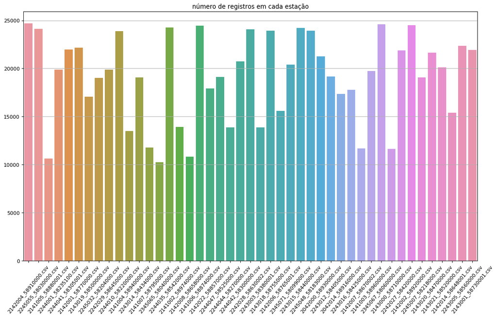

```python
graficoHistNumRegistros()
```

## As estações possuem mais do que 10000 registros no mínimo e no maximo algo em torno de 25000;

- usar uma abordagem multitask pode trazer o modelo mais próximo de ser eficaz para aplicação de deep learning.
- talvez depois tentar aprender com cada série e transferir o aprendizado para outras, assim, tendo a soma de todos os registros como parametro de treino

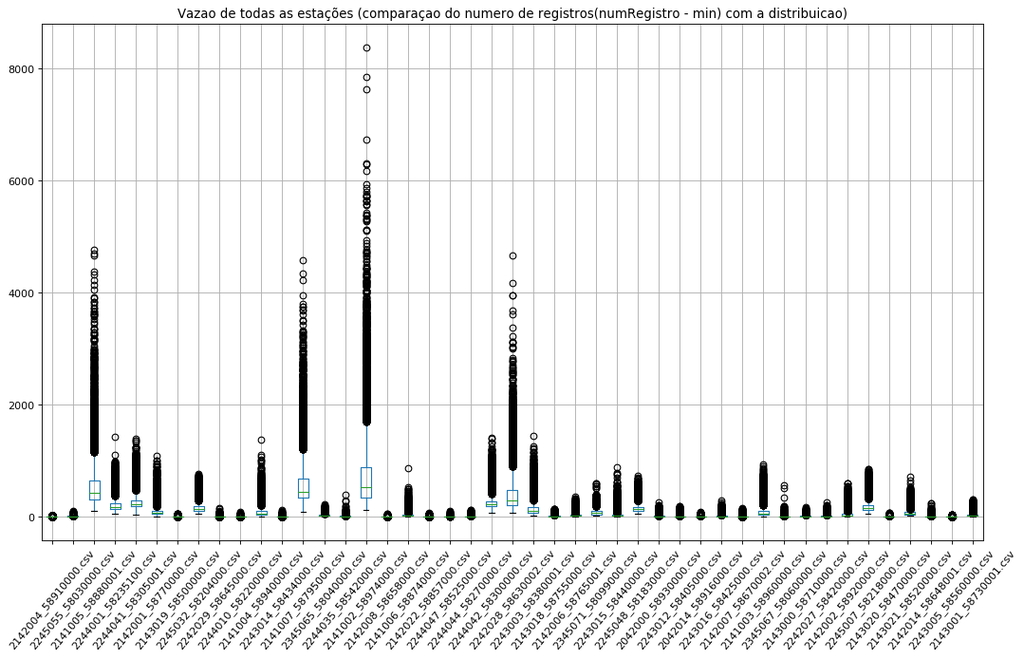

```python
graficoBoxPlot()
```

## As previsões de Vazão possuem muitos outliers, talvez devido a ruidos ou ao método de aferir os valores que confiam em muitas variáveis estimadas, além da aleatoriedade natural do problema.

- As distribuições das estações são bem destoantes e apresentam um comportamento de dificil padronização.
- algumas estações tem os dados muito mais sujos (muitos outliers), com valores muito altos, provavelmente o multitask ajudará a rede a ignorar esses desvios.

(conteúdo interessante) https://www.google.com/url?sa=t&rct=j&q=&esrc=s&source=web&cd=28&ved=2ahUKEwjn-bjulPrgAhWwHbkGHc_aDfIQFjAbegQIDBAC&url=http%3A%2F%2Fpaginapessoal.utfpr.edu.br%2Feudesarantes%2Fdisciplinas%2Fhidrologia%2FMedicaodavazao.pdf%2Fat_download%2Ffile&usg=AOvVaw05KM00Baj2CJFJ1Cji679Q

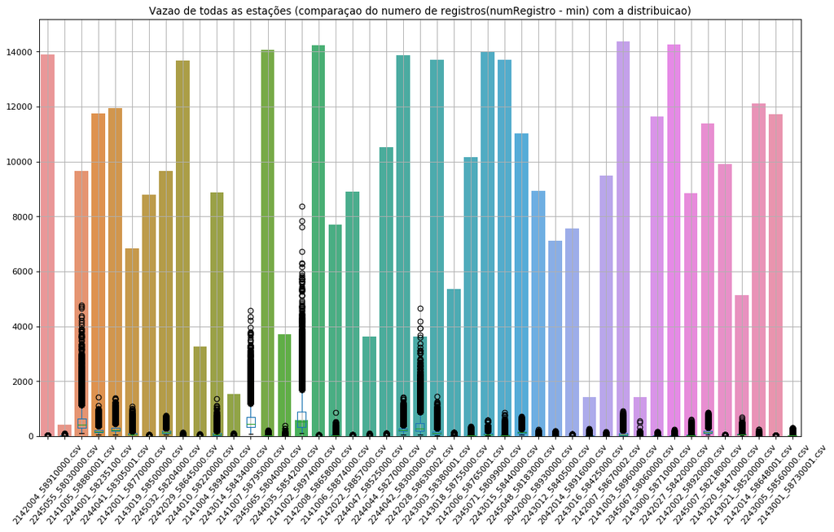

```python
graficoBarComBoxPlot()
```

# Os gráficos de barra tiveram seu mínimo decrescido para manter a escala, e não remover o histograma.

## o gráfico mostra a relação das estações com mais registros e sua distribuição.

- parece existir uma tendência das estações com menos registros terem dados mais discrepantes e com dados mais "estranhos"
- parece prudente descartarmos essas quatro estações com muito desvio

```python
print(listaArquivos[2], listaArquivos[12], listaArquivos[15], listaArquivos[22])
```

[output not shown]

link para consultar as bases http://www.snirh.gov.br/hidroweb/publico/medicoes_historicas_abas.jsf

# Estações com comportamento curioso

```python
# plt.subplots(9, 9)
def graficoDistribuicoes(i):
    plt.figure(figsize=(16, 10), dpi= 80, facecolor='w', edgecolor='k')
    for column, index in zip(BaseDadosConcatenada.iloc[:, i:i+9].items(), range(1, 10)):
#         print(column[1])
        plt.subplot(3, 3, index)
        sns.distplot(column[1].dropna())
    plt.show()
```

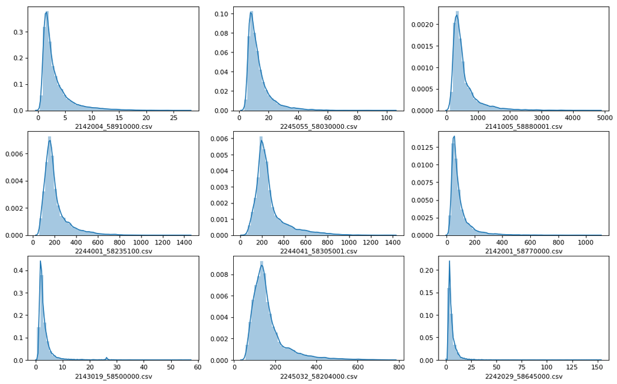

```python
graficoDistribuicoes(0)
```

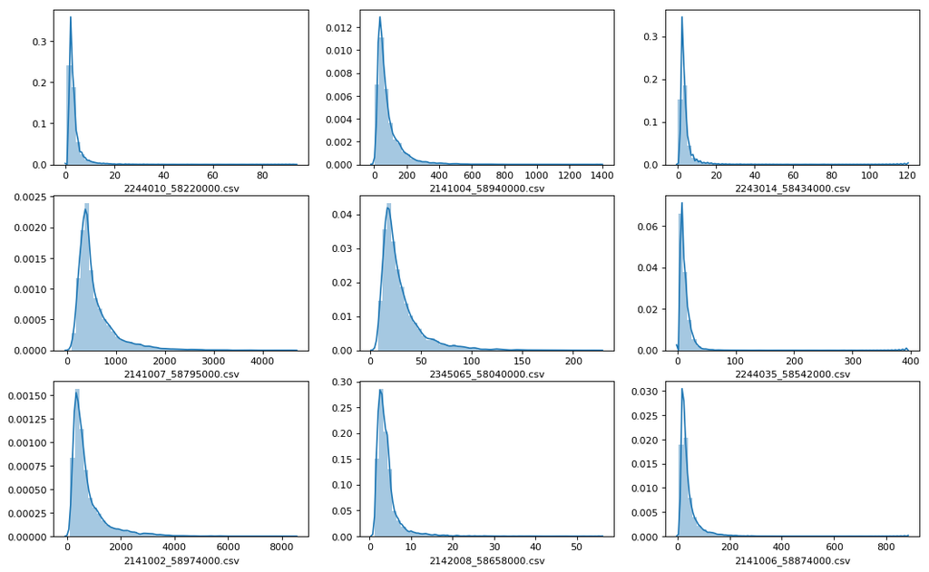

```python
graficoDistribuicoes(9)
```

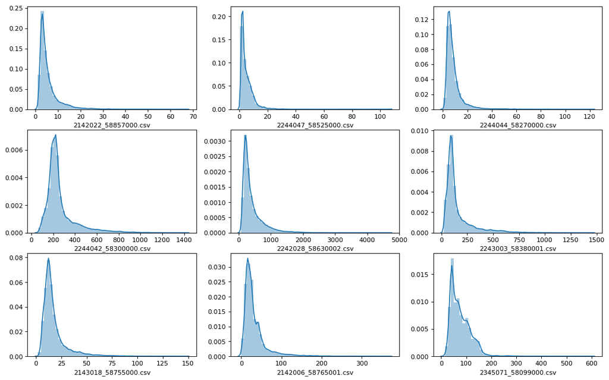

```python
graficoDistribuicoes(18)
```

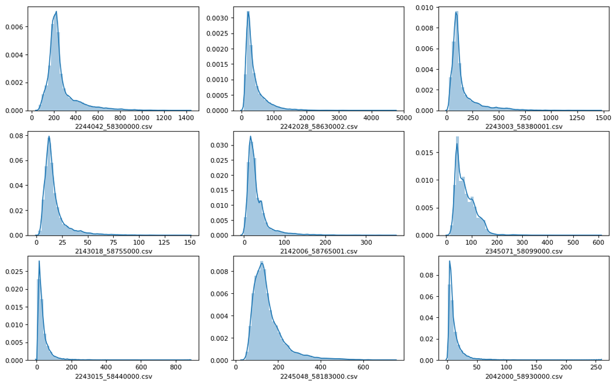

```python
graficoDistribuicoes(21)
```